# U5. La Revolución Argentina y el plan Krieger Vasena

Historia Económica Argentina · Clase 22

Sebastian Freille

Universidad Nacional de Córdoba

# Apertura y hoja de ruta

## Dónde quedamos

- Con **Illia**, la economía había recuperado producción y empleo; las exportaciones dieron más aire a la expansión.
- La inflación seguía presente, pero el golpe de junio de 1966 **no fue el desenlace de una crisis económica como la de 1962–63**.
- Onganía prometió resolver el desarrollo y la inflación suspendiendo la competencia política. Krieger Vasena sería el encargado del programa económico.

**Idea clave**

El plan de 1967 logró **desinflación con crecimiento**. Su continuidad exigía sostener una estructura de precios e ingresos que el propio crecimiento, los conflictos distributivos y el ciclo ganadero fueron modificando.

Gerchunoff y Llach (2007), cap. 7, pp. 301–303 y 325–329; De Pablo (1975), pp. 73–81.

## La pregunta de hoy

> ¿Cómo pudo bajar la inflación mientras crecían la producción y la cantidad de dinero? ¿Quiénes ganaron y quiénes perdieron con la estabilización? ¿Por qué esos resultados no aseguraron la continuidad del plan ni del gobierno?

**Tres problemas distintos**

**Estabilizar precios**, **sostener el crecimiento** y **construir apoyo político** no son la misma tarea. El episodio permite estudiar sus conexiones y sus tensiones.

## Mapa de la clase

1. **Bloque 1 — Onganía y el proyecto autoritario:** el golpe, los tres tiempos y la llegada de Krieger Vasena.
2. **Bloque 2 — El plan de marzo de 1967:** devaluación compensada, política de ingresos, dinero y cuentas públicas.
3. **Bloque 3 — Resultados y distribución:** inflación, crecimiento, salarios y precios relativos.
4. **Bloque 4 — Los límites del programa:** Cordobazo, ciclo ganadero, costo del crédito y salida hacia 1973.

# Bloque 1. Onganía y el proyecto autoritario

## [1.1] Un golpe con ambiciones de permanencia

- La **Revolución Argentina** comenzó en junio de 1966 con el derrocamiento de Illia y el ascenso de **Juan Carlos Onganía**.
- El proyecto pretendía transformar la economía y la sociedad antes de devolver el poder a los civiles. No ofrecía un calendario electoral.
- La suspensión de la actividad partidaria y la concentración del poder buscaban aislar las decisiones del gobierno de las demandas políticas y sectoriales.

**La promesa del régimen**

El desarrollo económico debía crear las condiciones de una futura estabilidad institucional. La cuestión era **quién decidía cuánto esperar y cómo repartir sus costos**.

Gerchunoff y Llach (2007), cap. 7, pp. 301–303.

## [1.2] Los tres tiempos de Onganía

| Etapa prometida | Objetivo | Supuesto del proyecto |
| --- | --- | --- |
| **Tiempo económico** | Modernizar, invertir, ganar eficiencia | Posponer demandas facilitaría la acumulación |
| **Tiempo social** | Extender los beneficios del crecimiento | La distribución podría esperar al éxito productivo |
| **Tiempo político** | Construir un orden institucional estable | La legitimidad llegaría después del desarrollo |

**El problema de la secuencia**

Los conflictos por salarios, empleo y representación ocurrían **durante** el tiempo económico. No podían ponerse en pausa por decreto.

Gerchunoff y Llach (2007), cap. 7, pp. 302–304; interpretación de la secuencia para la clase.

## [1.3] Autoridad no era lo mismo que consenso

- El golpe encontró expectativas favorables en sectores que identificaban al gobierno de Illia con lentitud e ineficiencia; parte de la dirigencia sindical también recibió al nuevo gobierno con expectativa.
- La **Noche de los Bastones Largos**, en 1966, mostró el carácter represivo de la intervención universitaria. Se sumaron censura y controles sobre la vida cultural.
- La ausencia de competencia electoral reducía los canales institucionales para tramitar desacuerdos. La quietud de 1967–68 no significaba ausencia de oposición.

Gerchunoff y Llach (2007), cap. 7, pp. 301–304.

## [1.4] De Salimei a Krieger Vasena

- **Néstor Salimei** condujo la economía durante los primeros meses: intervención de ingenios azucareros y conflictos por la racionalización portuaria.
- En el BCRA, **Felipe Tami** proponía una estrategia gradual: pacto entre empresarios y trabajadores, reducción del déficit y ajustes cambiarios periódicos.
- Entre fines de 1966 y comienzos de 1967 cambió el equipo. **Adalbert Krieger Vasena** asumió con la intención de lanzar una estabilización más drástica.

**Un gobierno, distintas orientaciones**

El acuerdo sobre modernizar no resolvía las diferencias entre nacionalistas, desarrollistas y liberales acerca de **cómo** hacerlo.

Gerchunoff y Llach (2007), cap. 7, pp. 325–326.

## [1.5] El punto de partida importaba

- En 1966 se había frenado el crecimiento tras la fuerte expansión de 1964–65. La inflación seguía cerca del **30 % anual**.
- De Pablo señala reservas brutas equivalentes a **tres o cuatro meses de importaciones**, pero reservas netas negativas a comienzos de 1967.
- La economía disponía de la capacidad productiva ampliada en los años anteriores; también persistía una fuerte dependencia de insumos y equipos importados.

**Ni crisis terminal ni hoja en blanco**

El programa debía estabilizar una economía que venía de crecer y se había desacelerado, con **poco margen externo**. No bastaba con recuperar el producto perdido en una gran recesión.

De Pablo (1975), pp. 60 y 62–63; Gerchunoff y Llach (2007), cap. 7, pp. 320–321.

# Bloque 2. El plan de marzo de 1967

## [2.1] Qué diagnóstico revelaban las medidas

- La estrategia actuaba sobre **costos y expectativas**: dólar, salarios y precios industriales debían dejar de reajustarse en una espiral.
- El **13 de marzo de 1967** se anunció el Plan de Estabilización y Desarrollo: un cambio inicial de precios seguido por compromisos de estabilidad.
- La baja del déficit y la apertura cambiaria acompañaban esa estrategia; la contracción general de la demanda **no fue su mecanismo central**.

**Más que una etiqueta**

De Pablo lo caracteriza como **heterodoxo por sus instrumentos**. El perfil liberal del ministro no convierte automáticamente al programa en una estabilización monetarista.

Gerchunoff y Llach (2007), pp. 326–327; De Pablo (1975), pp. 67–70.

## [2.2] Las piezas del programa

| Instrumento | Medida | Mecanismo buscado |
| --- | --- | --- |
| **Cambio** | Salto a 350 pesos m/n por dólar y paridad fija | Alterar expectativas de devaluación |
| **Comercio** | Retenciones y reducción de aranceles | Amortiguar el traslado de la devaluación |
| **Salarios** | Ajuste inicial y suspensión de paritarias | Frenar la propagación por costos salariales |
| **Precios** | Acuerdo con grandes empresas | Coordinar decisiones de remarcación |
| **Fisco** | Tarifas, impuestos y retenciones | Mejorar ingresos y reducir desequilibrios |
| **Dinero y crédito** | Acompañar la demanda de pesos y ampliar crédito | Sostener la actividad durante la desinflación |

Gerchunoff y Llach (2007), pp. 326–328; De Pablo (1975), pp. 63–70.

## [2.3] La promesa de la última devaluación

- El dólar quedó en **350 pesos moneda nacional**. Gerchunoff y Llach resumen el salto como **40 %**; De Pablo precisa **255 → 350**, alrededor de **37 %**, para operaciones financieras y exportaciones no tradicionales.
- Se buscaba que el nuevo nivel fuera suficientemente alto para evitar otra devaluación y modificar las expectativas.
- El mercado cambiario se liberalizó, pero la cotización quedó **fijada por la política económica**.

**Dos conceptos diferentes**

**Libertad para operar en cambios** no implica **flotación del tipo de cambio**. Una paridad fija requiere intervención y divisas para sostenerla.

Gerchunoff y Llach (2007), p. 326; De Pablo (1975), pp. 63 y 68, nota 28.

## [2.4] ¿Por qué una devaluación compensada?

- Una devaluación sin compensaciones habría elevado los precios internos de los exportables y el costo de los bienes importados.
- Las **retenciones de 16 %, 20 % o 25 %**, según el producto tradicional, absorbían parte del aumento del ingreso exportador en pesos.
- La **baja de aranceles** amortiguaba el encarecimiento de las importaciones. Las compensaciones fueron **parciales y diferentes según el producto**.

**El dólar no era el único precio relevante**

El programa intentaba mejorar la posición cambiaria sin trasladar toda la devaluación a alimentos e insumos. Además, las retenciones aportaban **recaudación fiscal**.

Gerchunoff y Llach (2007), pp. 326–328; De Pablo (1975), pp. 63–65.

## [2.5] El mecanismo, con números

Si el precio externo permanece constante, el ingreso unitario del exportador es proporcional a $e(1-t_x)$; el costo del importado, a $e(1+t_m)$.

| Ejemplo didáctico | Antes | Después | Variación |
| --- | --- | --- | --- |
| Dólar: $e$ | 250 | 350 | +40 % |
| Exportable: retención de 0 % a 25 % | 250 | 262,5 | +5 % |
| Importado: arancel de 100 % a 50 % | 500 | 525 | +5 % |

- $e$: pesos por dólar; $t_x$: retención; $t_m$: arancel. Se omiten otros costos e impuestos.
- **Las alícuotas y el punto inicial son ilustrativos**: permiten aislar la compensación, no reconstruir cada operación de 1967.

Elaboración didáctica a partir de De Pablo (1975), p. 64 y nota 19. No son datos observados.

## [2.6] Salarios y precios: compromisos desiguales

- Se suspendieron las **convenciones colectivas** y el gobierno dispuso ajustes salariales. El aumento inicial debía cerrar la negociación por un período prolongado.
- Las grandes empresas acordaron moderar sus precios a cambio de beneficios, entre ellos el acceso de sus compradores al crédito de consumo.
- Los salarios quedaban bajo decisiones obligatorias del gobierno; el acuerdo empresarial tenía otra forma de aplicación y cumplimiento.

**No era un pacto social entre iguales**

La coordinación económica descansaba en un régimen que restringía la negociación sindical. Esa asimetría importaba para la **distribución** y para la **legitimidad** del programa.

Gerchunoff y Llach (2007), pp. 326–327; De Pablo (1975), pp. 66–69 y 74.

## [2.7] Bajar el déficit y aumentar la inversión

- Subieron tarifas y tributos; las retenciones incorporaron una fuente adicional de ingresos. La mejora fiscal no se basó simplemente en recortar todo el gasto.
- La inversión pública real creció cerca de **55 % entre 1966 y 1970**, según Gerchunoff y Llach: energía, transporte e integración territorial.
- **El Chocón, Atucha, Zárate–Brazo Largo y el túnel Santa Fe–Paraná** recibieron impulso en esta etapa; sus inicios y terminaciones no coincidieron todos con el mandato del ministro.

**Una precisión de De Pablo**

Algunas cuentas de la época registraban colocaciones de deuda como ingresos. **Menor desequilibrio de caja no equivale necesariamente a igual mejora del déficit económico**.

Gerchunoff y Llach (2007), pp. 327–328; De Pablo (1975), pp. 64–65 y 69–70.

## [2.8] Más dinero con menos inflación

- Al disminuir la inflación esperada, conservar pesos resultaba menos costoso: podía aumentar la **demanda de saldos reales**.
- La cantidad nominal de dinero creció **29,8 % en 1967** y **26,8 % en 1968**. Hubo entrada de divisas y, en 1968, reducción de encajes bancarios.
- Esa expansión acompañó la remonetización y el crédito. Una oferta monetaria rígida habría dificultado sostener simultáneamente la actividad y la paridad.

**La condición importa**

Emitir no impedía desinflar **si crecía la demanda de pesos**. Esa demanda podía revertirse si volvían las expectativas de inflación o devaluación.

Gerchunoff y Llach (2007), p. 327; De Pablo (1975), pp. 65–68, cuadro 4.

## [2.9] Capitales: alivio externo y vulnerabilidad

- La paridad prometida y las tasas internas atrajeron capitales de corto plazo y repatriación de fondos. Las reservas brutas pasaron de **US$ 265,7 a 768,6 millones** entre fines de 1966 y fines de 1967.
- También ingresaron inversiones y se compraron empresas locales. Una adquisición cambia la propiedad; **no implica por sí sola nueva capacidad instalada**.
- Con más divisas era posible financiar importaciones y sostener el crecimiento, pero la continuidad dependía en parte de la confianza en el programa.

De Pablo (1975), p. 68, nota 31; Gerchunoff y Llach (2007), p. 328.

# Bloque 3. Resultados y distribución

## [3.1] Desinflación con crecimiento

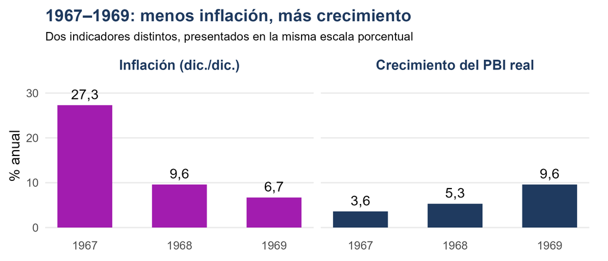

Inflación: De Pablo (1975), cuadro 1, p. 60, costo de vida, diciembre/diciembre. PBI: Gerchunoff y Llach (2007), p. 327. Series de fuentes y revisiones distintas; no se empalman sus estimaciones de PBI.

## [3.2] Qué logró el programa

- El producto creció **3,6 % en 1967**, **5,3 % en 1968** y **9,6 % en 1969**, según Gerchunoff y Llach.
- El costo de vida aumentó **9,6 % durante 1968** y **6,7 % durante 1969**: la desinflación fue sustantiva, aunque no llegó a precios constantes.
- La inversión pública, el crédito y el alivio externo ayudaron a sostener la demanda. La estabilización no necesitó una recesión inmediata para dar resultados.

**Cuidado con las cifras anuales**

El **7,6 % de 1969** que aparece en Gerchunoff y Llach compara promedios anuales; el **6,7 %** compara diciembre con diciembre. Responden a preguntas distintas.

Gerchunoff y Llach (2007), pp. 323 y 327–328; De Pablo (1975), cuadro 1, p. 60.

## [3.3] El crecimiento no empezó en marzo de 1967

- Gerchunoff y Llach sitúan el episodio dentro de una **expansión más larga, 1963–1973**, favorecida por el contexto internacional.
- La mecanización, las semillas mejoradas y la productividad agrícola ampliaron la capacidad de exportar. La inversión de los años de Frondizi había aumentado la capacidad industrial.
- El plan actuó sobre esa economía: facilitó crédito, inversión y financiamiento externo, pero **no creó desde cero sus recursos productivos**.

**Resultado observado no es efecto causal**

Comparar antes y después describe la trayectoria. Para atribuir todo el crecimiento al plan habría que separar **herencia productiva, contexto externo y nuevas políticas**.

Gerchunoff y Llach (2007), cap. 7, pp. 305–321; De Pablo (1975), pp. 62–63 y 73.

## [3.4] Quién recibió qué: precios relativos

| Grupo o actividad | Canal del programa | Tensión distributiva |
| --- | --- | --- |
| **Asalariados** | Ajustes administrados; menor inflación | Los precios podían erosionar los salarios entre ajustes |
| **Agro exportador** | Devaluación menos retenciones | Ganancia cambiaria limitada; luego pesaban los costos internos |
| **Industria** | Crédito, demanda y menor costo arancelario | Beneficios distintos según insumos, protección y deuda |
| **Estado** | Retenciones, tarifas e impuestos | Más recursos, pero también costos políticos |
| **Acreedores y deudores** | Suba de tasas reales al desinflar | Transferencia hacia acreedores si la tasa nominal no se ajustaba |

Síntesis de Gerchunoff y Llach (2007), pp. 326–329, y De Pablo (1975), pp. 64–80. Son canales; el efecto neto varía entre sectores y períodos.

## [3.5] Salario real no es participación salarial

- El **salario real** mide cuánto compra un salario: $w/P_c$, con $P_c$ como índice de precios al consumidor.
- La **participación salarial** mide qué proporción del ingreso recibe el trabajo. Depende del salario, el empleo y el valor agregado total.
- Puede crecer el empleo y, aun así, caer esa participación si la masa salarial aumenta menos que el ingreso total.

**Para no confundir resultados**

**Más producción**, **más puestos de trabajo**, **más poder de compra por trabajador** y **mayor proporción del ingreso para el trabajo** son cuatro afirmaciones diferentes.

Distinción analítica para interpretar De Pablo (1975), cuadro 6, pp. 71–74.

## [3.6] La distribución: importa el año de comparación

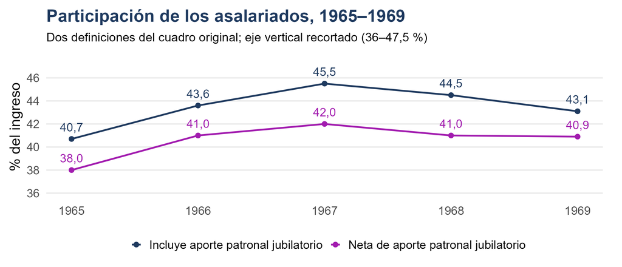

- Desde el máximo de **1967**, la participación retrocede; frente a **1965**, el balance es distinto.

De Pablo (1975), cuadro 6, p. 71. Participación en el ingreso, con y sin aporte patronal jubilatorio; no es una medida de desigualdad entre hogares.

## [3.7] La distribución condicionaba la continuidad

- El congelamiento anunciado no eliminó toda modificación posterior de salarios. Hubo ajustes administrados y recuperación salarial durante 1969.
- De Pablo registra aumentos nominales de **20,3 % y 21,5 % en 1969** para el peón industrial soltero y casado, respectivamente; esas categorías **no representan todo el empleo**.
- La recuperación del salario real corregía pérdidas anteriores, pero reabría la discusión sobre costos, márgenes y precios.

**El dilema del programa**

Sostener el ancla salarial trasladaba costos a los trabajadores. Corregir esos costos exigía revisar la coordinación de precios e ingresos sobre la que descansaba la desinflación.

De Pablo (1975), cuadro 5, p. 66; pp. 74–75 y nota 38; Gerchunoff y Llach (2007), p. 329.

## [3.8] Un dólar fijo no congela el tipo de cambio real

El tipo de cambio real puede expresarse como $q=eP^*/P$: $e$ es el dólar en pesos, $P^*$ el nivel de precios externo y $P$ el interno.

- Con $e$ fijo, si los precios internos suben más que los externos, **$q$ cae**: el peso se aprecia en términos reales.
- Bajar retenciones podía compensar parte de la pérdida de rentabilidad exportadora. Pero la compensación tenía un límite y reducía ingresos fiscales.
- La inflación residual acumulada erosionaba el margen creado por la devaluación inicial, incluso cuando la inflación anual era mucho menor.

Formalización didáctica de Gerchunoff y Llach (2007), pp. 315 y 327–329; De Pablo (1975), p. 64.

# Bloque 4. Los límites del programa

## [4.1] El Cordobazo y la caída del ministro

- En **mayo de 1969**, la movilización obrera y estudiantil en Córdoba quebró la imagen de orden del régimen.
- El conflicto mostró que crecimiento agregado y mejora de algunos indicadores no resolvían las demandas laborales ni el rechazo al autoritarismo.
- Krieger Vasena dejó el ministerio en **junio de 1969**. Lo sucedió **José María Dagnino Pastore**, que mantuvo elementos centrales del programa.

**Dos cronologías**

**La gestión de Krieger Vasena terminó en 1969; la estrategia estabilizadora se prolongó hasta mediados de 1970.** Tampoco el Cordobazo produjo la caída inmediata de Onganía.

Gerchunoff y Llach (2007), pp. 303–304 y 328–329; De Pablo (1975), pp. 61–63.

## [4.2] ¿Se cayó por la política o por la economía?

| Lectura | Qué ayuda a entender | Pregunta que deja abierta |
| --- | --- | --- |
| **Gerchunoff y Llach** | El buen desempeño macroeconómico no impidió el quiebre político y la pérdida de confianza | ¿Qué ajustes habría necesitado el programa para continuar? |
| **De Pablo** | Había fallas de diseño aun sin suponer un cambio político: carne, crédito y rigidez de precios | ¿Cómo corregirlas sin desarmar las expectativas? |

**La pregunta contrafáctica**

Si no hubiera ocurrido el Cordobazo, ¿el plan podía durar **tal como estaba**? De Pablo responde que la firmeza política no bastaba para resolver sus problemas económicos.

Gerchunoff y Llach (2007), pp. 328–329; De Pablo (1975), pp. 55–56 y 73–82. Los énfasis difieren; ninguno obliga a negar la otra dimensión.

## [4.3] La carne: estabilidad presente, escasez futura

- La hacienda es **bien de capital y bien de consumo**: faenar hoy aumenta la oferta de carne, pero reduce el stock que puede reproducirse mañana.
- De Pablo vincula los bajos precios relativos de 1968–69 con la liquidación de existencias. Esa mayor oferta ayudaba a contener el costo de vida en el corto plazo.
- Luego se redujo la faena y creció la demanda externa. El precio de la carne subió con fuerza desde 1970.

**Un mecanismo intertemporal**

La carne barata podía sostener la desinflación de hoy a costa de una **menor oferta futura**. En esa interpretación, parte del problema se gestó durante el éxito del plan.

De Pablo (1975), pp. 75–79; Gerchunoff y Llach (2007), p. 329.

## [4.4] De un precio relativo a la inflación general

| Eslabón | Mecanismo |
| --- | --- |
| **Menor oferta de carne y mayor demanda externa** | Sube el precio relativo de la carne |
| **Canasta familiar más cara** | Cae el poder de compra del salario |
| **Intento de recuperar ingresos** | Reclamos salariales y ajustes de otros precios |
| **Propagación y validación monetaria** | El aumento sectorial puede convertirse en inflación persistente |

**No es una identidad automática**

El aumento de un precio puede elevar el índice **una vez**. Para explicar inflación persistente hay que explicar **la repetición y propagación** de los ajustes.

De Pablo (1975), pp. 76–79. La distinción entre impacto inicial y propagación explicita el mecanismo discutido por el autor.

## [4.5] El crédito podía abundar y encarecerse

- Si la inflación baja mucho y la tasa nominal baja poco, aumenta el **costo real del crédito**: aproximadamente, $r=i-\pi$ para el rendimiento realizado.
- Un ejemplo: con tasa nominal de 20 %, pasar de inflación de 30 % a 10 % eleva la tasa real exacta de **−7,7 % a +9,1 %**: $(1+i)/(1+\pi)-1$.
- De Pablo destaca la transferencia de **deudores netos hacia acreedores netos** y la presión sobre empresas acostumbradas a financiarse a tasas reales negativas.

**La estabilización tampoco era neutral**

Más liquidez y crédito podían coexistir con una carga financiera real mayor. Para las decisiones futuras importa la **inflación esperada**; para la carga efectivamente pagada, la realizada.

De Pablo (1975), pp. 66 y 79–80. Las tasas 20 %, 30 % y 10 % son un ejemplo didáctico, no observaciones históricas.

## [4.6] La rigidez que ayudó a empezar

- Fijar dólar, salarios y compromisos de precios ayudó a coordinar expectativas. Pero la economía seguía cambiando: productividad, oferta sectorial, demanda e ingresos relativos.
- Ante un desajuste, un congelamiento rígido dejaba dos salidas problemáticas: **reprimir el ajuste** o **revisar las promesas nominales**.
- Para De Pablo, estabilizar requería admitir ajustes relativos y gestionar la transición desde una economía acostumbrada a la inflación.

**El problema de salida**

El programa necesitaba una regla para **cambiar precios relativos sin reiniciar la espiral**. La promesa de que ciertos ajustes serían los últimos hacía esa adaptación más difícil.

De Pablo (1975), pp. 80–82; en 1969 comenzaron intentos limitados de flexibilizar el acuerdo, nota 54.

## [4.7] De Onganía a la salida electoral

| Período | Gobierno y orientación | Consecuencia |
| --- | --- | --- |
| **1969–mediados de 1970** | Onganía / Dagnino Pastore | Persisten las anclas, con tensiones salariales, cambiarias y en la carne |
| **1970–1971** | Levingston; Moyano Llerena y luego Ferrer | Nueva devaluación; giro nacional desarrollista y apoyo a empresas locales |
| **1971–1973** | Lanusse | Crece la prioridad de la salida política; se debilita la conducción económica |

- La sucesión militar no consolidó la estabilización. Aumentaron inflación y desequilibrios fiscales mientras se preparaba el retorno electoral.

Gerchunoff y Llach (2007), pp. 303–304 y 329–331.

## [4.8] La desinflación se revirtió

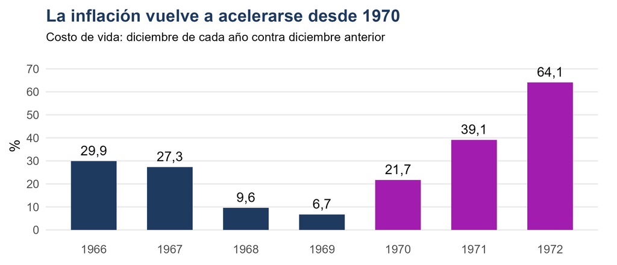

- El giro ascendente comenzó en **1970**. El éxito inicial no se convirtió en un régimen duradero de baja inflación.

De Pablo (1975), cuadro 1, p. 60. Costo de vida, diciembre de cada año contra diciembre anterior; no promedios anuales.

## [4.9] Qué deja la Revolución Argentina

- La dictadura llegó a 1973 sin cumplir la secuencia prometida: el **tiempo político** se impuso por el desgaste del régimen, no por haber concluido el desarrollo.
- Quedaban una economía que había crecido, inversión y capacidades productivas; también inflación creciente y conflictos sin resolver.
- El retorno del peronismo abriría otra tentativa de coordinar salarios y precios, esta vez con un **Pacto Social** y una base política distinta.

**Puente a la próxima clase**

La pregunta cambia: ¿podría una concertación entre gobierno, sindicatos y empresarios sostener lo que la coordinación autoritaria no había podido preservar?

Gerchunoff y Llach (2007), cierre del cap. 7 y apertura del cap. 8; De Pablo (1975), pp. 55–56.

# Cierre

## Ideas fuerza

1. Onganía intentó **posponer la política y la distribución** hasta completar el desarrollo; los conflictos ocurrieron durante el proceso.
2. Krieger Vasena combinó **devaluación compensada, ancla cambiaria y política de ingresos** con crédito e inversión pública.
3. La **desinflación con crecimiento** fue real; no permite atribuir toda la expansión de la década al plan.
4. **Salarios, participación salarial, rentabilidad exportadora y costo del crédito** cambiaron de manera diferente. La estabilización tuvo efectos distributivos.
5. El Cordobazo quebró el proyecto político. **De Pablo identifica además fallas económicas**: ciclo ganadero, tasas reales y rigidez de precios.

## Preguntas para llevarse

- ¿Por qué una devaluación de alrededor del 40 % no aumentó en igual proporción todos los precios internos de bienes transables?
- ¿Cómo puede aumentar la cantidad de dinero mientras baja la inflación? ¿Qué condiciones hacen posible ese resultado?
- ¿Qué diferencia hay entre recuperar salario real y recuperar participación en el ingreso?
- ¿Por qué el precio de la carne y la tasa real de interés son centrales en la crítica de De Pablo?
- Sin Cordobazo, ¿qué cambios económicos habría necesitado el plan para continuar? Distinguir lo documentado del contrafáctico.

## Bibliografía de la clase

**Lecturas principales**

- **Gerchunoff, P. y Llach, L. (2007).** *El ciclo de la ilusión y el desencanto. Un siglo de políticas económicas argentinas*, cap. 7, **«Una primavera económica (1963–1973)»**. Especialmente pp. 301–304 y 325–331.
- **De Pablo, J. C. (1975).** «Precios relativos, distribución del ingreso y planes de estabilización: la experiencia de la Argentina durante **1967–70**». *Desarrollo Económico*, **15 (57), 55–83**. Especialmente secciones 2–4.

Ambos textos se encuentran en la compilación local «HEA-parte 2-Cap 5.pdf». La paginación citada corresponde a los textos reproducidos. El «1967–76» del programa es una errata: el artículo estudia 1967–70.